# Лабораторная работа № 2

Модель боевых действий

Анна Светцова

1132230807@pfur.ru

Российский университет дружбы народов

2026-10-08

# Информация

## Докладчик

**Анна Светцова**

Российский университет дружбы народов

1132230807@pfur.ru

# Вводная часть

## Актуальность

- Модели Ланчестера позволяют исследовать динамику численности противоборствующих сторон
- Разные типы взаимодействия приводят к различным системам дифференциальных уравнений
- Вычислительный эксперимент позволяет сравнить сценарии и оценить влияние параметров модели

## Цель работы

Исследовать две модели боевых действий для варианта 58:

- противоборство регулярных войск;
- взаимодействие регулярных войск и партизанских отрядов.

Дополнительно исследовать влияние одного из коэффициентов эффективности.

# Постановка задачи

## Исходные данные

Для варианта 58:

- начальная численность армии X: $x(0)=100000$;
- начальная численность армии Y: $y(0)=10000$;
- коэффициенты модели постоянны;
- функции подкрепления зависят от времени.

## Регулярные войска

Первая модель:

$$\frac{dx}{dt}
=
-0.12x-0.9y+\sin t,$$

$$\frac{dy}{dt}
=
-0.3x-0.1y+\cos t.$$

Потери каждой стороны линейно зависят от численности обеих армий.

## Регулярные войска и партизаны

Вторая модель:

$$\frac{dx}{dt}
=
-0.25x-0.96y+\sin(2t)+1,$$

$$\frac{dy}{dt}
=
-0.25xy-0.3y+\cos(20t)+1.$$

Нелинейный член $xy$ отражает особенности потерь партизанских отрядов.

# Основной эксперимент

## Первая модель

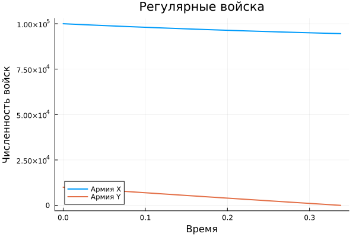

Численности обеих сторон изменяются во времени в соответствии с линейной системой Ланчестера.

## Вторая модель

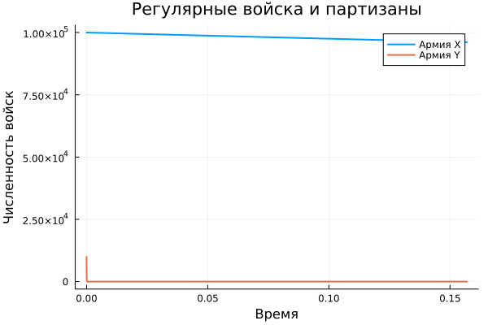

Нелинейный член приводит к существенно иной динамике изменения численности сторон.

## Сравнение моделей

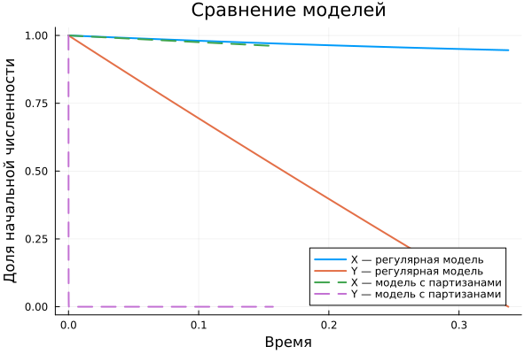

Для сравнения используются нормированные численности относительно начальных значений.

# Параметрическое исследование

## Изменяемый параметр

Для регулярной модели исследован коэффициент $c$, характеризующий эффективность действий армии X против армии Y:

$$c \in \{0.2,\;0.3,\;0.4\}.$$

Для каждого значения повторно решается система и фиксируются итоговые значения.

## Влияние коэффициента $c$

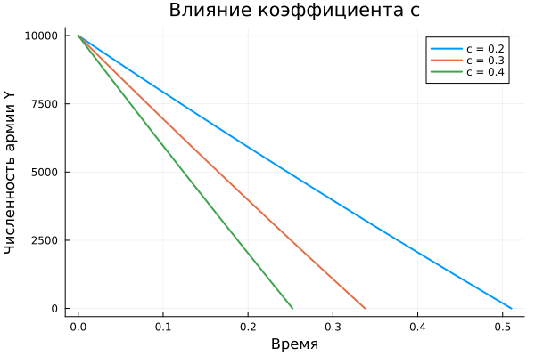

Изменение эффективности действий одной стороны заметно меняет скорость снижения численности противника.

# Воспроизводимость

## Организация вычислений

- исходный код оформлен в литературном стиле;
- сформированы Julia-скрипты;
- созданы Jupyter Notebook;
- создана документация Quarto;
- основной и параметрический notebooks выполнены отдельно;
- результаты сохранены в CSV и PNG.

# Результаты

## Основные результаты

- реализованы две модели боевых действий для варианта 58;
- построены временные зависимости численностей армий;
- выполнено сравнение линейной и нелинейной моделей;
- проведено параметрическое исследование коэффициента эффективности;
- вычисления представлены в воспроизводимом виде.

# Итоги

## Вывод

Модели Ланчестера позволяют описать динамику противоборствующих сторон с помощью систем дифференциальных уравнений.

Добавление нелинейного взаимодействия, характерного для модели с партизанскими отрядами, существенно изменяет динамику системы.

Изменение коэффициента эффективности одной из сторон также заметно влияет на продолжительность и результат противостояния.